# NYPD Shooting Incident Data Report

6/16/2023

List of every shooting incident that occurred in NYC going back to 2006 through the end of the previous calendar year.

This is a breakdown of every shooting incident that occurred in NYC going back to 2006 through the end of the previous calendar year. This data is manually extracted every quarter and reviewed by the Office of Management Analysis and Planning before being posted on the NYPD website. Each record represents a shooting incident in NYC and includes information about the event, the location and time of occurrence. In addition, information related to suspect and victim demographics is also included. This data can be used by the public to explore the nature of shooting/criminal activity. Please refer to the attached data footnotes for additional information about this dataset.

## Load and Tidy Data

Filter out columns that will not be used. I do not plan on using the following columns: **PRECINCT**, **JURISDICTION_CODE**, **LOCATION_DESC**, **X_COORD_CD**, **Y_COORD_CD**, and **Lon_Lat**.

```r
df = read_csv("https://data.cityofnewyork.us/api/views/833y-fsy8/rows.csv?accessType=DOWNLOAD")

df_2 = df %>% select(INCIDENT_KEY,
                   OCCUR_DATE,
                   OCCUR_TIME,
                   BORO,
                   STATISTICAL_MURDER_FLAG,
                   PERP_AGE_GROUP,
                   PERP_SEX,
                   PERP_RACE,
                   VIC_AGE_GROUP,
                   VIC_SEX,
                   VIC_RACE,
                   Latitude,
                   Longitude)

lapply(df_2, function(x) sum(is.na(x)))
```

```
## $INCIDENT_KEY
## [1] 0
##
## $OCCUR_DATE
## [1] 0
##
## $OCCUR_TIME
## [1] 0
##
## $BORO
## [1] 0
##
## $STATISTICAL_MURDER_FLAG
## [1] 0
##
## $PERP_AGE_GROUP
## [1] 9344
##
## $PERP_SEX
## [1] 9310
##
## $PERP_RACE
## [1] 9310
##
## $VIC_AGE_GROUP
## [1] 0
##
## $VIC_SEX
## [1] 0
##
## $VIC_RACE
## [1] 0
##
## $Latitude
## [1] 10
##
## $Longitude
## [1] 10
```

```r
head(df_2)
```

```
## # A tibble: 6 × 13
##   INCIDENT_KEY OCCUR_DATE OCCUR_TIME BORO  STATISTICAL_MURDER_F…¹ PERP_AGE_GROUP
##          <dbl> <chr>      <time>     <chr> <lgl>                  <chr>
## 1    228798151 05/27/2021 21:30      QUEE… FALSE                  <NA>
## 2    137471050 06/27/2014 17:40      BRONX FALSE                  <NA>
## 3    147998800 11/21/2015 03:56      QUEE… TRUE                   <NA>
## 4    146837977 10/09/2015 18:30      BRONX FALSE                  <NA>
## 5     58921844 02/19/2009 22:58      BRONX TRUE                   25-44
## 6    219559682 10/21/2020 21:36      BROO… TRUE                   <NA>
## # ℹ abbreviated name: ¹STATISTICAL_MURDER_FLAG
## # ℹ 7 more variables: PERP_SEX <chr>, PERP_RACE <chr>, VIC_AGE_GROUP <chr>,
## #   VIC_SEX <chr>, VIC_RACE <chr>, Latitude <dbl>, Longitude <dbl>
```

There are many data points which are incomplete. This meaning that they do not have entries for every column. I attributed this to potentially be caused by several factors (unknown info, open investigation, etc.) so will display these gaps in the data as “unknown”.

Data Types:

- **STRINGS:** INCIDENT_KEY
- **FACTORS:** BORO, PERP_AGE_GROUP, PERP_SEX, PERP_RACE, VIC_AGE_GROUP, VIC_SEX, VIC_RACE

```r
df_2 = df_2 %>%
  replace_na(list(PERP_AGE_GROUP = "Unknown", PERP_SEX = "Unknown", PERP_RACE = "Unknown"))

# Remove outliers in data
df_2 = subset(df_2, PERP_AGE_GROUP!="1020" & PERP_AGE_GROUP!="224" & PERP_AGE_GROUP!="940")

df_2$PERP_AGE_GROUP = recode(df_2$PERP_AGE_GROUP, UNKNOWN = "Unknown")
df_2$PERP_SEX = recode(df_2$PERP_SEX, U = "Unknown")
df_2$PERP_RACE = recode(df_2$PERP_RACE, UNKNOWN = "Unknown")
df_2$VIC_SEX   = recode(df_2$VIC_SEX, U = "Unknown")
df_2$VIC_RACE   = recode(df_2$VIC_RACE, UNKNOWN = "Unknown")
df_2$INCIDENT_KEY = as.character(df_2$INCIDENT_KEY)
df_2$BORO = as.factor(df_2$BORO)
df_2$PERP_AGE_GROUP = as.factor(df_2$PERP_AGE_GROUP)
df_2$PERP_SEX = as.factor(df_2$PERP_SEX)
df_2$PERP_RACE = as.factor(df_2$PERP_RACE)
df_2$VIC_AGE_GROUP = as.factor(df_2$VIC_AGE_GROUP)
df_2$VIC_SEX = as.factor(df_2$VIC_SEX)
df_2$VIC_RACE = as.factor(df_2$VIC_RACE)

summary(df_2)
```

```
##  INCIDENT_KEY        OCCUR_DATE         OCCUR_TIME                  BORO
##  Length:27309       Length:27309       Length:27309      BRONX        : 7935
##  Class :character   Class :character   Class1:hms        BROOKLYN     :10932
##  Mode  :character   Mode  :character   Class2:difftime   MANHATTAN    : 3572
##                                        Mode  :numeric    QUEENS       : 4094
##                                                          STATEN ISLAND:  776
##
##
##  STATISTICAL_MURDER_FLAG PERP_AGE_GROUP     PERP_SEX              PERP_RACE
##  Mode :logical           (null) :  640   (null) :  640   BLACK         :11431
##  FALSE:22043             <18    : 1591   F      :  424   Unknown       :11146
##  TRUE :5266              18-24  : 6222   M      :15436   WHITE HISPANIC: 2339
##                          25-44  : 5687   Unknown:10809   BLACK HISPANIC: 1314
##                          45-64  :  617                   (null)        :  640
##                          65+    :   60                   WHITE         :  283
##                          Unknown:12492                   (Other)       :  156
##  VIC_AGE_GROUP      VIC_SEX                                VIC_RACE
##  <18    : 2839   F      : 2615   AMERICAN INDIAN/ALASKAN NATIVE:   10
##  1022   :    1   M      :24683   ASIAN / PACIFIC ISLANDER      :  404
##  18-24  :10085   Unknown:   11   BLACK                         :19438
##  25-44  :12279                   BLACK HISPANIC                : 2646
##  45-64  : 1863                   Unknown                       :   66
##  65+    :  181                   WHITE                         :  698
##  UNKNOWN:   61                   WHITE HISPANIC                : 4047
##     Latitude       Longitude
##  Min.   :40.51   Min.   :-74.25
##  1st Qu.:40.67   1st Qu.:-73.94
##  Median :40.70   Median :-73.92
##  Mean   :40.74   Mean   :-73.91
##  3rd Qu.:40.82   3rd Qu.:-73.88
##  Max.   :40.91   Max.   :-73.70
##  NA's   :10      NA's   :10
```

## Visualization and Analysis

First I decided to plot all of the incidents by longitude and latitude over a map of the city. This creates a user friendly way to visualize the density of incidents but will not be extracting data from this figure. I chose to not knit this document to pdf so this map can still be used as intended. While this data set is just NYC it would have also been interesting to look at data of areas surrounding NYC for comparison.

```r
leaflet_map <- leaflet() %>%
  addTiles() %>%
  setView(lng = -74.00, lat = 40.71, zoom = 10)

leaflet_markers <- leaflet_map %>%
  addCircleMarkers(data = df_2, lng = ~Longitude, lat = ~Latitude, radius = 0.01, color = "red", fillOpacity = 0.5)

leaflet_markers
```

[interactive chart not shown]

Occurrence by Borough

*Brooklyn is the 1st in terms of the number of incidents, followed by Bronx and Queens respectively.* Likewise, the number of murder cases follows the same pattern as that of incidents.

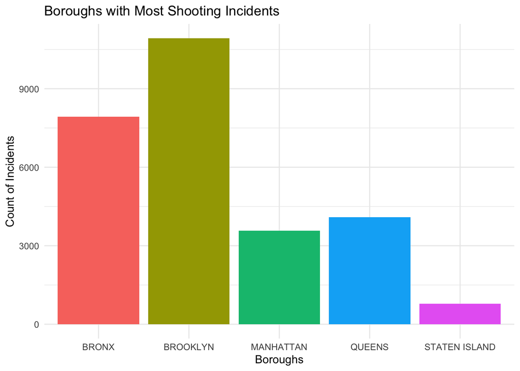

```r
boro_plot <- ggplot(df_2, aes(x = BORO, fill = BORO)) +
  geom_bar() +
  labs(title = "Boroughs with Most Shooting Incidents",
       x = "Boroughs",
       y = "Count of Incidents") +
  theme_minimal() +
  theme(legend.position = "none")
boro_plot
```

```r
borough_murder_cases <- table(df_2$BORO, df_2$STATISTICAL_MURDER_FLAG)
borough_murder_cases
```

```
##
##                 FALSE TRUE
##   BRONX          6393 1542
##   BROOKLYN       8810 2122
##   MANHATTAN      2942  630
##   QUEENS         3284  810
##   STATEN ISLAND   614  162
```

Occurrence by Date and Time

- There are increased frequency of an incident during the weekend
- Incidents historically happen later in the day and at night.

```r
df_2$OCCUR_DAY <- wday(mdy(df_2$OCCUR_DATE), label = TRUE)
df_2$OCCUR_HOUR <- hour(hms(as.character(df_2$OCCUR_TIME)))

day_of_week_counts <- df_2 %>%
  count(OCCUR_DAY)

hour_of_day_counts <- df_2 %>%
  count(OCCUR_HOUR)
```

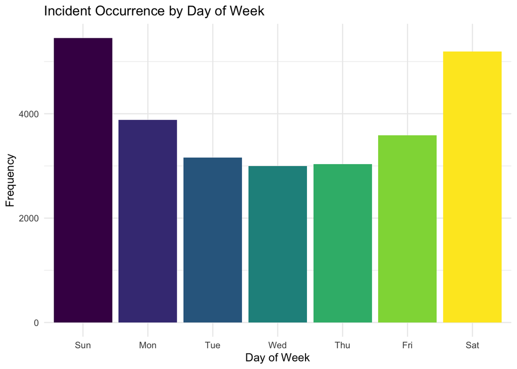

```r
week_plot <- ggplot(day_of_week_counts, aes(x = OCCUR_DAY, y = n, fill = OCCUR_DAY)) +
  geom_col() +
  labs(title = "Incident Occurrence by Day of Week",
       x = "Day of Week",
       y = "Frequency") +
  theme_minimal() +
  theme(legend.position = "none")
week_plot
```

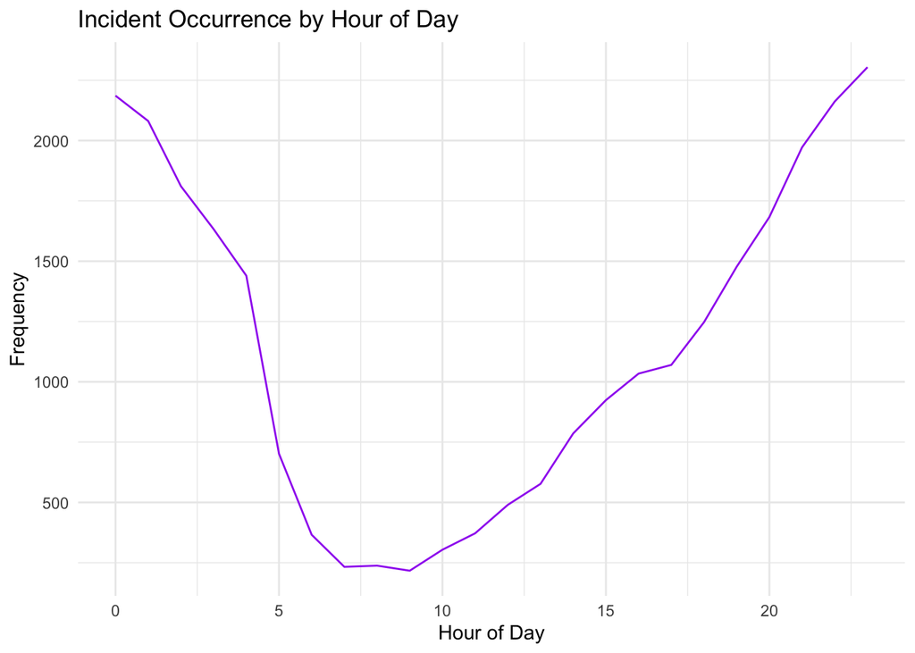

```r
day_plot <- ggplot(hour_of_day_counts, aes(x = OCCUR_HOUR, y = n)) +
  geom_line(color = "purple") +
  labs(title = "Incident Occurrence by Hour of Day",
       x = "Hour of Day",
       y = "Frequency") +
  theme_minimal()
day_plot
```

To dive further into days of the week I created a heat map of incident frequency by weekday and month. This allows us to look if certain days of the week have increased incident occurrence during certain times of the year. Additionally this can be further explored by replacing day of the week with day of the month. This revealed that weekends in the summer have an even higher occurence than weekends at other points in the year.

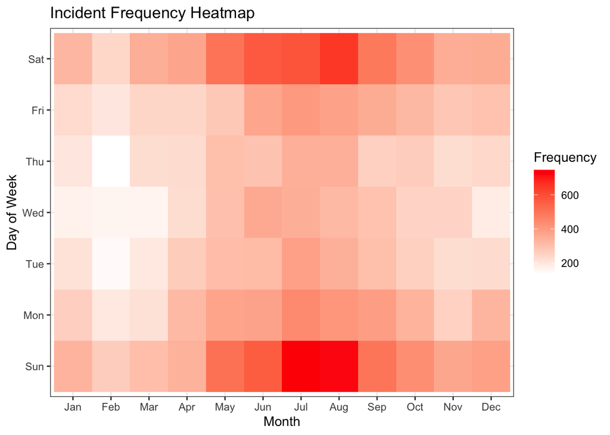

```r
df_2$OCCUR_DATE <- mdy(df_2$OCCUR_DATE)

df_2$Month <- month(df_2$OCCUR_DATE, label = TRUE)
df_2$Day <- wday(df_2$OCCUR_DATE, label = TRUE)

summary_df <- df_2 %>%
  group_by(Month, Day) %>%
  summarise(Frequency = n())

ggplot(summary_df, aes(x = Month, y = Day, fill = Frequency)) +
  geom_tile() +
  scale_fill_gradient(low = "white", high = "red") +
  labs(title = "Incident Frequency Heatmap", x = "Month", y = "Day of Week") +
  theme_bw()
```

Victim and Perpetrator Profiles

- Largest occurrence of incidents with age groups 18-24 & 25-44.
- Overall more incidents involving males than females.
- Large occurrence of incidents with victim and perpetrator in same age group

```r
age_group_table <- table(df_2$PERP_AGE_GROUP, df_2$VIC_AGE_GROUP)
age_group_table
```

```
##
##            <18 1022 18-24 25-44 45-64  65+ UNKNOWN
##   (null)    57    0   181   340    57    5       0
##   <18      484    0   621   397    77   10       2
##   18-24    788    1  2758  2294   329   40      12
##   25-44    262    0  1516  3352   479   43      35
##   45-64     20    0    76   327   177   12       5
##   65+        0    0     1    25    23   11       0
##   Unknown 1228    0  4932  5544   721   60       7
```

```r
sex_table <- table(df_2$PERP_SEX, df_2$VIC_SEX)
sex_table
```

```
##
##               F     M Unknown
##   (null)     72   568       0
##   F          72   351       1
##   M        1666 13764       6
##   Unknown   805 10000       4
```

```r
race_table <- table(df_2$PERP_RACE, df_2$VIC_RACE)
race_table
```

```
##
##                                  AMERICAN INDIAN/ALASKAN NATIVE
##   (null)                                                      1
##   AMERICAN INDIAN/ALASKAN NATIVE                              0
##   ASIAN / PACIFIC ISLANDER                                    0
##   BLACK                                                       4
##   BLACK HISPANIC                                              0
##   Unknown                                                     5
##   WHITE                                                       0
##   WHITE HISPANIC                                              0
##
##                                  ASIAN / PACIFIC ISLANDER BLACK BLACK HISPANIC
##   (null)                                               15   446             58
##   AMERICAN INDIAN/ALASKAN NATIVE                        0     2              0
##   ASIAN / PACIFIC ISLANDER                             52    53             13
##   BLACK                                               157  9058            803
##   BLACK HISPANIC                                       18   531            344
##   Unknown                                             113  8523            999
##   WHITE                                                13    37             23
##   WHITE HISPANIC                                       36   788            406
##
##                                  Unknown WHITE WHITE HISPANIC
##   (null)                               0    12            108
##   AMERICAN INDIAN/ALASKAN NATIVE       0     0              0
##   ASIAN / PACIFIC ISLANDER             0    12             24
##   BLACK                               25   197           1187
##   BLACK HISPANIC                       5    36            380
##   Unknown                             24   187           1295
##   WHITE                                1   157             52
##   WHITE HISPANIC                      11    97           1001
```

## Identify Bias

The first source of bias I would like to address is my own. I have never lived in New York City but have of course seen TV, movies, and other media that portrays the city. Based on this previous media I have consumed I would have guessed that Manhattan would have the lowest incident occurrence of the boroughs. This would certainly be very different from someone who grew up in New York City and had personal experiences adding to their bias.

The data may reflect biases in the demographics of individuals involved in shooting incidents. It is important to examine whether certain racial or ethnic groups are disproportionately represented in the data, which could indicate systemic biases in policing practices.

Finally I would like to acknowledge geographic bias. It is very likely that police presence differs between boroughs. This could result in a reporting bias where some boroughs appear to have more incidents than others where in reality a higher police presence results in more recorded incidents where in reality the number of incidents may be similar between boroughs they are just not being recorded.